# Mapping Burn Severity of Colorado's Two Largest Wildfires

Max Warnock | October 2026

This project maps burn severity for the 2020 Cameron Peak and East Troublesome fires with satellite imagery, and looks at the watersheds, vegetation recovery, and homes affected.

**Full analysis:** the complete notebooks, with all of the code, are available on GitHub: [Mapping Burn Severity of Colorado's Two Largest Wildfires](https://github.com/maxwarnock/Colorado_Wildfire_Burn_Severity/tree/main/code)

## The 2020 fires

In 2020, Colorado had the two largest wildfires in its history. The Cameron Peak Fire started on August 13 in the mountains west of Fort Collins and burned 208,913 acres. The East Troublesome Fire started on October 14 in Grand County and burned 193,694 acres.

Cameron Peak burned for almost four months and East Troublesome for about seven weeks ([Butzer, 2020](https://www.denver7.com/news/wildfire/containment-at-cameron-peak-fire-states-largest-wildfire-on-record-increases-to-97); [Miller, 2020](https://www.denver7.com/news/wildfire/east-troublesome-fire-second-largest-in-colorado-history-declared-100-contained)). Not every part of a fire burns the same. Some areas only lose their grass and shrubs, while others lose entire forests. This project maps how severely each part of the two fires burned, and answers three questions:

1. Where did the fires burn most severely, by watershed?
2. How has vegetation recovered from 2021 to 2026?
3. How much of the high severity area is in or near homes in the wildland urban interface (WUI)?

## Data

The project uses five main data sources:

| Data | Source | Used for |
| --- | --- | --- |
| Fire perimeters | [National Interagency Fire Center (NIFC)](https://data-nifc.opendata.arcgis.com/) | The final outline of each fire |
| Satellite imagery | [NASA Harmonized Landsat and Sentinel-2 (HLS) v2.0](https://hls.gsfc.nasa.gov/) | Summer images from 2019 to 2026, for burn severity and vegetation recovery |
| Burn severity maps | [Monitoring Trends in Burn Severity (MTBS)](https://www.mtbs.gov/) | The official 2020 maps, to check this project's map |
| Watersheds | [USGS Watershed Boundary Dataset](https://www.usgs.gov/national-hydrography/watershed-boundary-dataset) | HUC12 subwatersheds |
| Wildland urban interface | [WUI Mapping Tool](https://github.com/maxwarnock/WUI_Mapping_Tool) | My 2019 map of the WUI in Colorado |

## Mapping burn severity

The project uses NASA's Harmonized Landsat and Sentinel-2 (HLS) imagery, which combines the Landsat 8/9 and Sentinel-2 satellites into one 30m dataset. For every summer from 2019 to 2026, the clear images from June 1 to September 30 were combined into one median image for each fire ([Howe et al., 2022](https://doi.org/10.3390/rs14205249); [Parks et al., 2018](https://doi.org/10.3390/rs10060879)).

Burn severity was mapped with the differenced Normalized Burn Ratio (dNBR). NBR is high for healthy vegetation and low for burned land, so the drop in NBR from the summer before the fires (2019) to the summer after (2021) shows how severely each 30m pixel burned:

$$ \text{NBR} = \frac{\text{NIR} - \text{SWIR2}}{\text{NIR} + \text{SWIR2}} \qquad \text{dNBR} = (\text{NBR}_{2019} - \text{NBR}_{2021}) \times 1000 $$

dNBR was then split into burn severity classes with the [Key and Benson (2006)](https://research.fs.usda.gov/treesearch/24042) thresholds, a standard made for the USDA Forest Service's FIREMON program that uses the same thresholds for every fire:

| Class | dNBR |
| --- | --- |
| Enhanced regrowth | below -100 |
| Unburned | -100 to 100 |
| Low | 100 to 270 |
| Moderate-low | 270 to 440 |
| Moderate-high | 440 to 660 |
| High | 660 and above |

## Burn severity

About a quarter of Cameron Peak (52,930 acres) and a fifth of East Troublesome (35,738 acres) burned at high severity. Another 26% of Cameron Peak and 31% of East Troublesome burned at moderate-high severity.

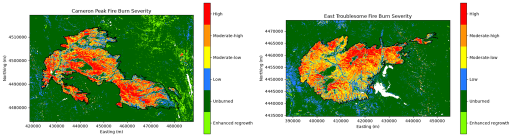

*Key and Benson burn severity classes for each fire, with the fire perimeter in black.*

To check the map, it was compared with the official [Monitoring Trends in Burn Severity (MTBS)](https://www.mtbs.gov/) maps ([Eidenshink et al., 2007](https://doi.org/10.4996/fireecology.0301003)). The two maps agree on about 70% of the area inside the perimeters (71% at Cameron Peak and 68% at East Troublesome). Kappa, which takes out the agreement expected by chance, is 0.61 and 0.54, which is substantial and moderate agreement ([Landis and Koch, 1977](https://doi.org/10.2307/2529310)). The Key and Benson map has less high severity than MTBS, which started High lower for these fires, at 490 and 540. But 92-96% of what Key and Benson calls high is also high in MTBS, so its high severity areas are a conservative estimate.

## Where did the fires burn most severely?

The burned area was split into HUC12 subwatersheds, the smallest watersheds in the USGS Watershed Boundary Dataset. Seven subwatersheds had 20% or more of their area burn at high severity:

- **Cameron Peak:** Little Beaver Creek (40%), Miller Fork (37%), Sheep Creek (33%), Upper Buckhorn Creek (28%), and Hague Creek (22%), in the Cache la Poudre and Big Thompson river basins
- **East Troublesome:** Headwaters Willow Creek (32%) and Onahu Creek-Colorado River (27%), in the Colorado River headwaters

High severity areas lose the most ground cover, so these subwatersheds are the most at risk of erosion after the fires.

[interactive chart not shown]

*Percent of each subwatershed burned at high severity, with the fire perimeters in black. Hover over a subwatershed to see its name.*

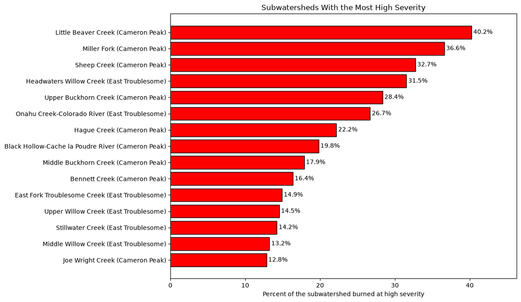

*The 15 subwatersheds with the highest percent of their area burned at high severity.*

## How has the vegetation recovered?

Recovery was tracked with summer NDVI, a measure of how green the land is (Tucker, 1979). Each burned area was compared with unburned land outside the fires in the same summer, so a wet or dry summer isn't mistaken for recovery.

By 2026, the moderate-high and high severity areas had regained 39-46% of the greenness they lost. Most of it came back in the first three summers, and it has been slower since 2024. The high severity areas were the greenest before the fires, likely dense forest, and are now about as green as the moderate areas.

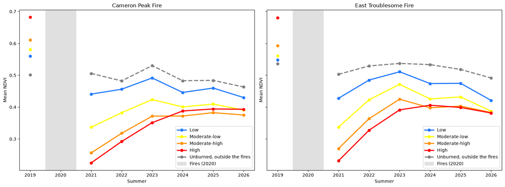

*Mean summer NDVI in each burn severity class, and on unburned land outside the fires (dashed gray).*

NDVI only measures greenness. Grass and shrubs can green up in a few years, but burned forest takes decades to grow back, so the forest is further from recovery than these numbers suggest.

## How much high severity burn was near homes?

The burn severity map was compared with a 2019 WUI map from my [WUI Mapping Tool](https://github.com/maxwarnock/WUI_Mapping_Tool), which follows the WUI definition of [Radeloff et al. (2005)](https://doi.org/10.1890/04-1413). The WUI is land where homes are mixed into wildland vegetation (intermix) or next to it (interface).

Very little of the high severity area was in the WUI itself: 374 acres at Cameron Peak and 80 acres at East Troublesome, less than 1% of each fire's high severity area. The WUI burned much less severely than the land around it, likely because homes are mostly in valleys and clearings with less dense forest.

Fire can still reach homes from outside the WUI, because embers can fly about 2.4km ahead of a fire (Radeloff et al., 2005). 28% of the high severity area at Cameron Peak and 14% at East Troublesome was within 2.4km of the WUI, mostly along Buckhorn Creek and the Cache la Poudre River at Cameron Peak, and in the Onahu Creek-Colorado River subwatershed at East Troublesome.

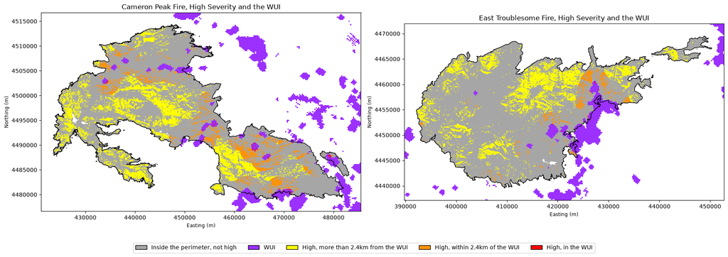

*High severity area by its distance to the WUI (purple).*

## Conclusion

Together, the two fires burned about 88,700 acres at high severity. The worst of it was in a few subwatersheds of the Cache la Poudre, Big Thompson, and Colorado rivers, which are the most at risk of erosion while the land recovers. By 2026, the high severity areas had regained less than half of their lost greenness. Very little high severity fire was in the WUI, but almost a quarter of it burned close enough for embers to reach homes.

The map was made from free satellite imagery with the same thresholds for every fire, and it matched the official MTBS maps on about 70% of the area. The same steps can be repeated for other fires and future years.

## Limitations

- The Key and Benson map has less high severity than MTBS, so the high severity areas in this project are on the low side
- Burn severity was mapped from satellite imagery and wasn't checked with field plots
- NDVI shows how green the land is, not whether the forest has grown back
- The WUI map has 250m pixels and is from 2019. Burn severity measures the vegetation, not damage to homes, so this project doesn't show which homes burned

## Additional Resources

The full project repository, with all of the notebooks and data, is available on GitHub:

**github.com/maxwarnock/Colorado_Wildfire_Burn_Severity**

The WUI map was made with my WUI Mapping Tool:

**github.com/maxwarnock/WUI_Mapping_Tool**

## References

Butzer, S. (2020). Cameron Peak Fire — Colorado's largest wildfire on record — is now 100% contained. *Denver7*. https://www.denver7.com/news/wildfire/containment-at-cameron-peak-fire-states-largest-wildfire-on-record-increases-to-97

Eidenshink, J., Schwind, B., Brewer, K., Zhu, Z.-L., Quayle, B., & Howard, S. (2007). A project for monitoring trends in burn severity. *Fire Ecology, 3*(1), 3-21. https://doi.org/10.4996/fireecology.0301003

Howe, A. A., Parks, S. A., Harvey, B. J., Saberi, S. J., Lutz, J. A., & Yocom, L. L. (2022). Comparing Sentinel-2 and Landsat 8 for burn severity mapping in western North America. *Remote Sensing, 14*(20), 5249. https://doi.org/10.3390/rs14205249

Key, C. H., & Benson, N. C. (2006). Landscape assessment (LA): Sampling and analysis methods. In D. C. Lutes et al. (Eds.), *FIREMON: Fire effects monitoring and inventory system* (Gen. Tech. Rep. RMRS-GTR-164-CD, pp. LA-1-LA-55). USDA Forest Service, Rocky Mountain Research Station.

Landis, J. R., & Koch, G. G. (1977). The measurement of observer agreement for categorical data. *Biometrics, 33*(1), 159-174. https://doi.org/10.2307/2529310

Miller, B. (2020). East Troublesome Fire, second-largest in Colorado history, declared 100% contained. *Denver7*. https://www.denver7.com/news/wildfire/east-troublesome-fire-second-largest-in-colorado-history-declared-100-contained

Parks, S. A., Holsinger, L. M., Voss, M. A., Loehman, R. A., & Robinson, N. P. (2018). Mean composite fire severity metrics computed with Google Earth Engine offer improved accuracy and expanded mapping potential. *Remote Sensing, 10*(6), 879. https://doi.org/10.3390/rs10060879

Radeloff, V. C., Hammer, R. B., Stewart, S. I., Fried, J. S., Holcomb, S. S., & McKeefry, J. F. (2005). The wildland-urban interface in the United States. *Ecological Applications, 15*(3), 799-805. https://doi.org/10.1890/04-1413

Tucker, C. J. (1979). Red and photographic infrared linear combinations for monitoring vegetation. *Remote Sensing of Environment, 8*(2), 127-150. https://doi.org/10.1016/0034-4257(79)90013-0

Warnock, M. (2026). *WUI Mapping Tool* (Version 1.0.0) [Computer software]. Zenodo. https://doi.org/10.5281/zenodo.23404697